# Lecture #4: Applications of the Integral: Areas & Arc Lengths

MATH 146 – Calculus II

Torin Quinlivan

tquinlivan@knox.edu

Knox College

December 23, 2025

## Geometric Meaning of the Riemann Sum?

What does

$$\int_a^b f(x) \, dx = \lim_{\Delta x \to 0} \sum_{i=1}^n f(x_i^*) \Delta x$$

actually mean?

## The Integral as the Area Between Functions

If $f(x) \ge g(x)$ everywhere on an interval $[a, b]$, then $\displaystyle\int_a^b f(x) - g(x) \, dx$ is the area between the graphs of the function.

Why?

$$\int_a^b f(x) - g(x) \, dx = \lim_{\Delta x \to 0} \sum_{i=1}^n [f(x_i^*) - g(x_i^*)] \Delta x$$

## Example: The Integral as the Area Between Functions

**Example:** Find the area of the region bounded by the graphs of the functions $y = x + 4$ and $y = 3 - \dfrac{x}{2}$, from $x = 1$ to $x = 5$.

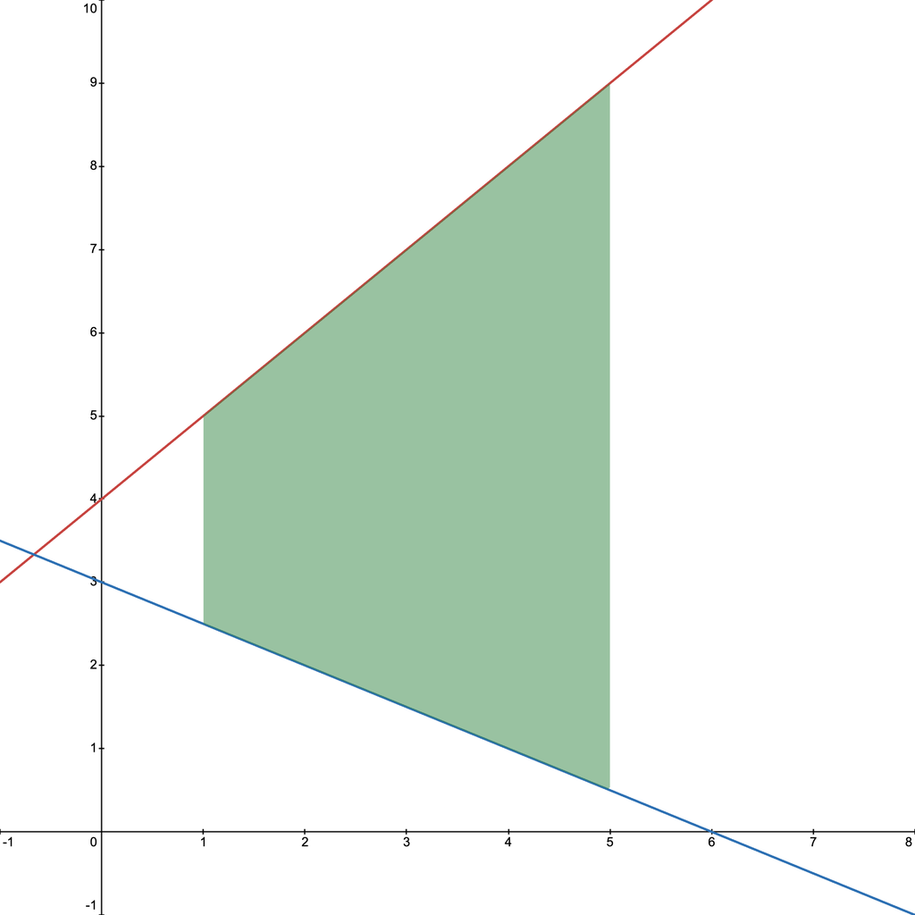

## Example: The Integral as the Area Between Functions

**Example:** Find the area of the region bounded by the graphs of the functions $y = x^3 - x$ and $y = x$.

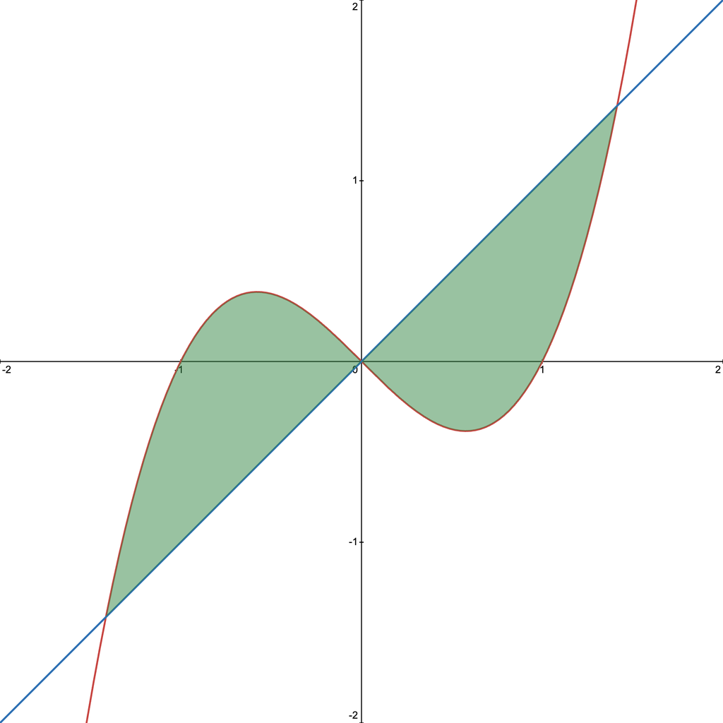

## Example: The Integral as the Area Between Functions

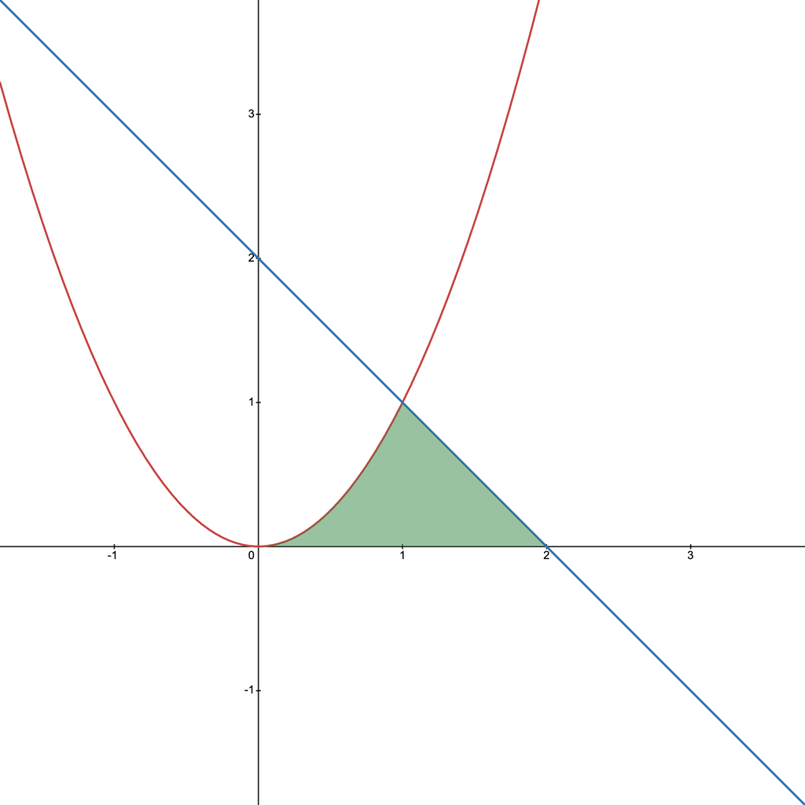

## Example: The Integral as the Area Between Functions

**Example:** Find the area of the region bounded by the graphs of the functions $x = \dfrac{(y - 2)^2}{3}$ and $y = 8 - x$.

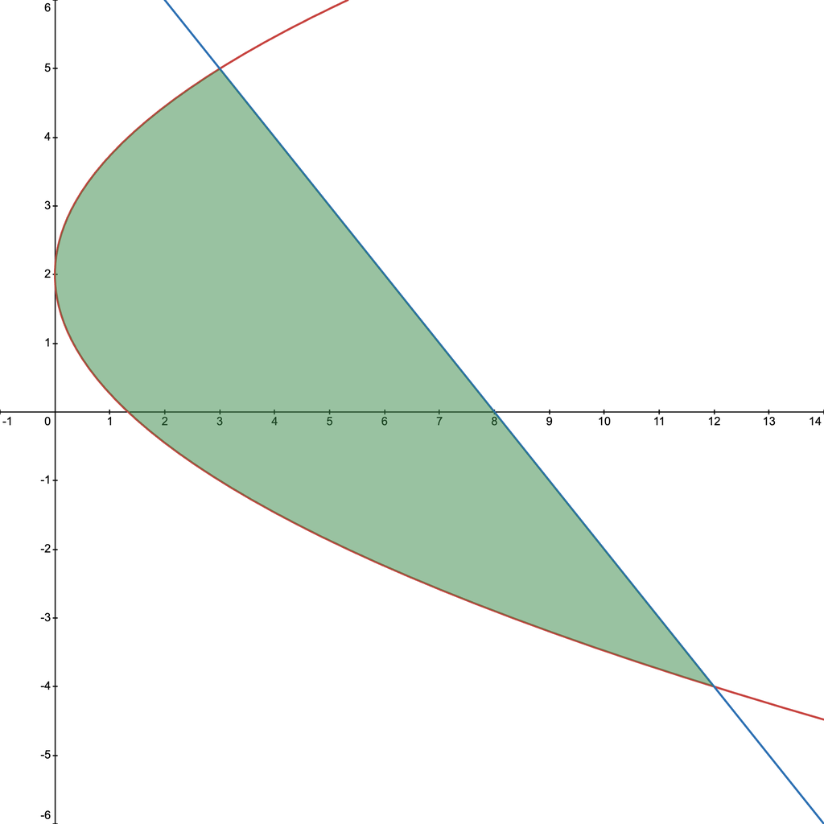

## The Integral as Arc Length

Given a curve, can you find its length?

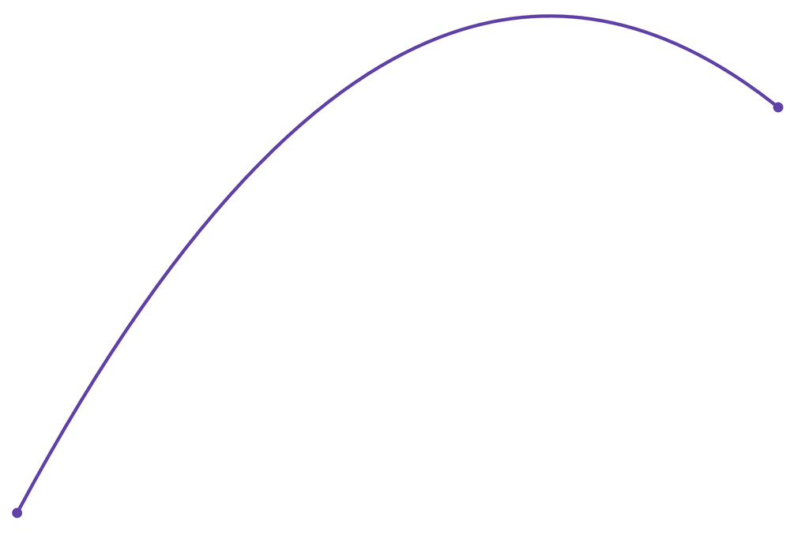

$$\textrm{Arc Length} \approx \sum_{i=1}^n \sqrt{(x_i - x_{i-1})^2 + (f(x_i) - f(x_{i-1}))^2}$$

## Mean Value Theorem

If $f(x)$ is continuous on $[a, b]$ and differentiable on $(a, b)$, then there exists a point $c$ such that $a \le c \le b$ and:

$$f'(c) = \frac{f(b) - f(a)}{b - a}.$$

## Mean Value Theorem

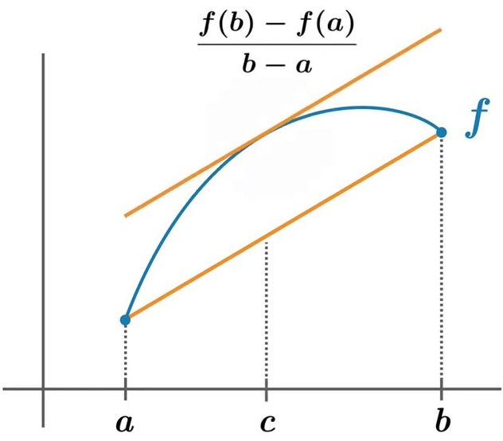

## The Integral as Arc Length

If $f(x)$ is a differentiable function on $[a, b]$, then the arc length of the graph of $f(x)$ over $[a, b]$ is

$$\int_a^b \sqrt{1 + [f'(x)]^2} \, dx.$$

## Example: The Integral as Arc Length

**Example:** Let $f(x) = 2x^{\frac{3}{2}}$. Calculate the arc length of the graph of f(x) over the interval $[0, 1]$.

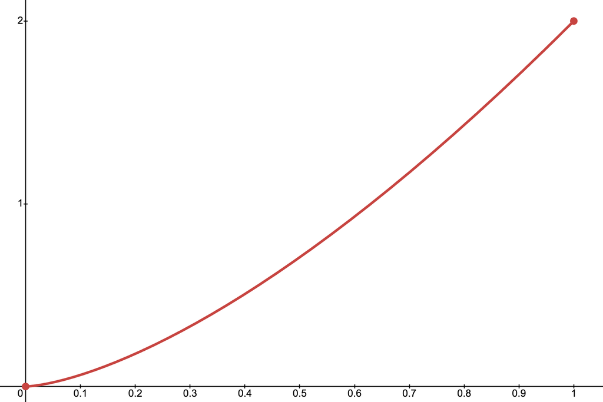

## Example: The Integral as Arc Length

**Example:** Find the circumference of a circle of radius $a$.

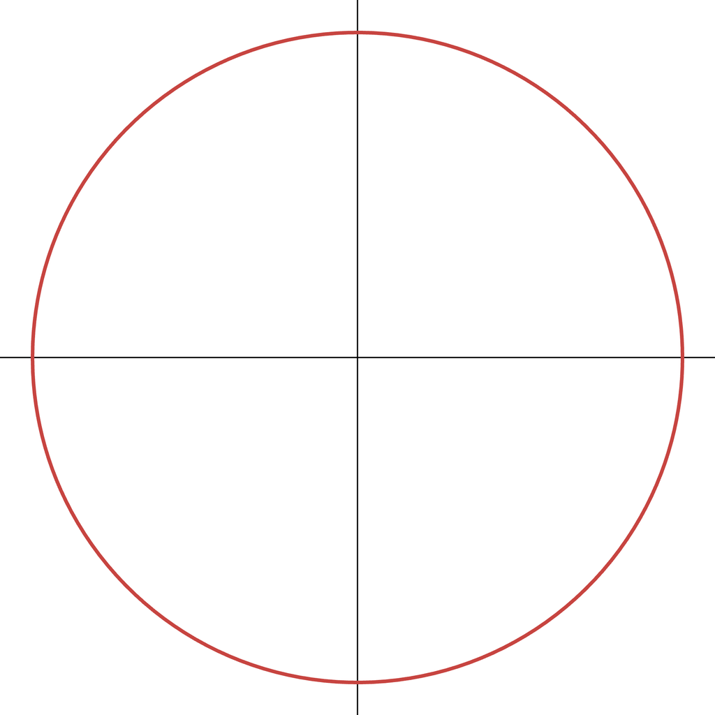

$$x^2 + y^2 = a^2$$